# DSP Analysis

# Properties

## Bulk Density

When multiple methods are used in measurements, such as bulk density, a ranking was used to alter how the methods are analyzed. For this example, core bulk density was favored because it was done on nearly all samples.

|  | Property | n |
| --- | --- | --- |
| 1 | BD_clod_13 | 437 |
| 2 | BD_clod_od | 437 |
| 3 | BD_compcav | 376 |
| 4 | BD_core_fld | 1520 |
| 5 | BD_fieldcore | 101 |
| 6 | BD_recon_moist | 679 |
| 7 | BD_recon_od | 679 |
| 8 | BD_recon13 | 679 |
| 9 | BD_whole_moist | 906 |
| 10 | BD_wholesoil | 80 |

### Data Prep

[output not shown]

[output cut: 3230 more lines]

## Fields used for comparison and data analysis

- typically test for mgmt or condition effect (typically MGMT)
- account for sampling scheme (plots)

### Comparable Layers

It is helpful to group horizons into similar layers for analysis. Look at the dsp_data file, you may want relabel the comp_layer for your project. Adjust the REGEX rules to seperate other horizons, parent materials etc.

**would like to be able to make this interactive somehow - look at all possible options and assign a ghl/comparable layer - this may be the toughest part**

```
##
##  2BCk  2Bk1  2Bk2  2Bk3  2Bkg 2Bkyg    2C   2Cg     A  A/Bw    A1    A2
##     2     6     4     1     1     1     1     1     8     3     3     3
##    A3    AB   Abk   ABk  ABk1  ABky    Ak   Akb   Akp  Akp1  Akp2  Akyb
##     1     9     1     1     1     1     9     1     1     3     4     1
##    Ap   Ap1   Ap2   Ap3  Apk1  Apk2   Apy   Bg1   Bg2   Bk1   Bkg  Bkyg
##    21    13    11     1     1     1     1     2     2     3     2     3
## Bkyg1 Bkyg2    Cg    Oi
##     1     1     1     2
```

```
##
##  2BCk  2Bk1  2Bk2  2Bk3  2Bkg 2Bkyg    2C   2Cg     A  A/Bw    A1    A2
##     2     6     4     1     1     1     1     1     8     3     3     3
##    A3    AB   Abk   ABk  ABk1  ABky    Ak   Akb   Akp  Akp1  Akp2  Akyb
##     1     9     1     1     1     1     9     1     1     3     4     1
##    Ap   Ap1   Ap2   Ap3  Apk1  Apk2   Apy   Bg1   Bg2   Bk1   Bkg  Bkyg
##    21    13    11     1     1     1     1     2     2     3     2     3
## Bkyg1 Bkyg2    Cg    Oi
##     1     1     1     2
```

```
## # A tibble: 0 x 4
## # Groups:   Soil, hor_desg [0]
## # ... with 4 variables: Soil <chr>, hor_desg <chr>, Comp_layer <fct>,
## #   n <int>
```

```
##
##                     2BCk 2Bk1 2Bk2 2Bk3 2Bkg 2Bkyg  2C 2Cg   A A/Bw  A1
##   O horizons           0    0    0    0    0     0   0   0   0    0   0
##   L horizons           0    0    0    0    0     0   0   0   0    0   0
##   A horizons           0    0    0    0    0     0   0   0   8    0   3
##   E horizons           0    0    0    0    0     0   0   0   0    0   0
##   Bk horizons          0    0    0    0    0     0   0   0   0    0   0
##   Bt horizons          0    0    0    0    0     0   0   0   0    0   0
##   Other B horizons     0    6    4    1    1     1   0   0   0    3   0
##   C horizons           2    0    0    0    0     0   1   1   0    0   0
##   Cr and R horizons    0    0    0    0    0     0   0   0   0    0   0
##   not-used             0    0    0    0    0     0   0   0   0    0   0
##   Sum                  2    6    4    1    1     1   1   1   8    3   3
##
##                      A2  A3  AB Abk ABk ABk1 ABky  Ak Akb Akp Akp1 Akp2
##   O horizons          0   0   0   0   0    0    0   0   0   0    0    0
##   L horizons          0   0   0   0   0    0    0   0   0   0    0    0
##   A horizons          3   1   0   1   0    0    0   9   1   1    3    4
##   E horizons          0   0   0   0   0    0    0   0   0   0    0    0
##   Bk horizons         0   0   0   0   0    0    0   0   0   0    0    0
##   Bt horizons         0   0   0   0   0    0    0   0   0   0    0    0
##   Other B horizons    0   0   9   0   1    1    1   0   0   0    0    0
##   C horizons          0   0   0   0   0    0    0   0   0   0    0    0
##   Cr and R horizons   0   0   0   0   0    0    0   0   0   0    0    0
##   not-used            0   0   0   0   0    0    0   0   0   0    0    0
##   Sum                 3   1   9   1   1    1    1   9   1   1    3    4
##
##                     Akyb  Ap Ap1 Ap2 Ap3 Apk1 Apk2 Apy Bg1 Bg2 Bk1 Bkg
##   O horizons           0   0   0   0   0    0    0   0   0   0   0   0
##   L horizons           0   0   0   0   0    0    0   0   0   0   0   0
##   A horizons           1  21  13  11   1    1    1   1   0   0   0   0
##   E horizons           0   0   0   0   0    0    0   0   0   0   0   0
##   Bk horizons          0   0   0   0   0    0    0   0   0   0   0   0
##   Bt horizons          0   0   0   0   0    0    0   0   0   0   0   0
##   Other B horizons     0   0   0   0   0    0    0   0   2   2   3   2
##   C horizons           0   0   0   0   0    0    0   0   0   0   0   0
##   Cr and R horizons    0   0   0   0   0    0    0   0   0   0   0   0
##   not-used             0   0   0   0   0    0    0   0   0   0   0   0
##   Sum                  1  21  13  11   1    1    1   1   2   2   3   2
##
##                     Bkyg Bkyg1 Bkyg2  Cg  Oi Sum
##   O horizons           0     0     0   0   2   2
##   L horizons           0     0     0   0   0   0
##   A horizons           0     0     0   0   0  84
##   E horizons           0     0     0   0   0   0
##   Bk horizons          0     0     0   0   0   0
##   Bt horizons          0     0     0   0   0   0
##   Other B horizons     3     1     1   0   0  42
##   C horizons           0     0     0   1   0   5
##   Cr and R horizons    0     0     0   0   0   0
##   not-used             0     0     0   0   0   0
##   Sum                  3     1     1   1   2 133
```

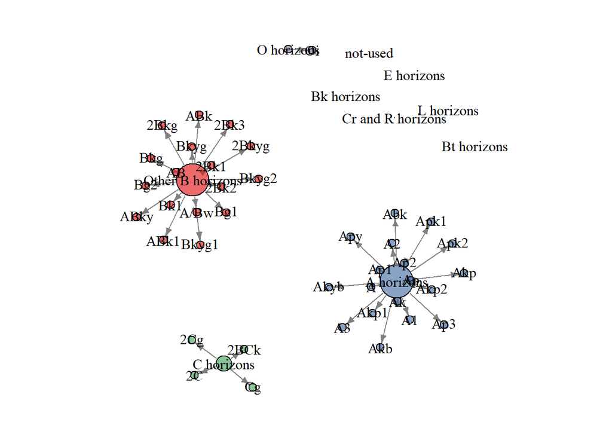

This will change the graphs and tests you see immediately. Output for all tests will be exported to the designated output location.

# select primary analysis field using dsp_labels

```
##  [1] "Name"             "DSP_Project"      "KSSL_Project"
##  [4] "Date"             "Collectors"       "UserPedonID"
##  [7] "labsampno"        "Layer_sequ"       "layerID"
## [10] "dsp_limslayer_ID" "Region.strata"    "Soil"
## [13] "Comparison"       "COND"             "Plot"
## [16] "Pedon"            "PlotID"           "Crop"
## [19] "AgronFeat"        "Pedon_ID"         "Hor_sequ"
## [22] "Hor_ID"           "Comp_layer"       "hor_desg"
## [25] "hor_top"          "hor_bot"          "hor_thick"
## [28] "Moist"            "AggStab"          "Bgluc"
## [31] "Pom_C"            "Pom_N"            "Pom_S"
## [34] "POX_C"            "CaCarb"           "Ca_amextr"
## [37] "CEC_ph7"          "Mg_amextr"        "K_amextr"
## [40] "Na_extr"          "BD_core_fld"      "FM_core"
## [43] "BD_recon13"       "BD_recon_od"      "BD_recon_moist"
```

[output cut: 18 more lines]

```
## [1] "Anal"               "LIMS_Table"         "Simple"
## [4] "Simple_explanation" "Label"
```

## SUMMARY PLOTS

**properties should be selectable via dropdown menu** **maybe grouping elements are also selectable**

```
## # A tibble: 0 x 2
## # Groups:   Property [0]
## # ... with 2 variables: Property <fct>, n <int>
```

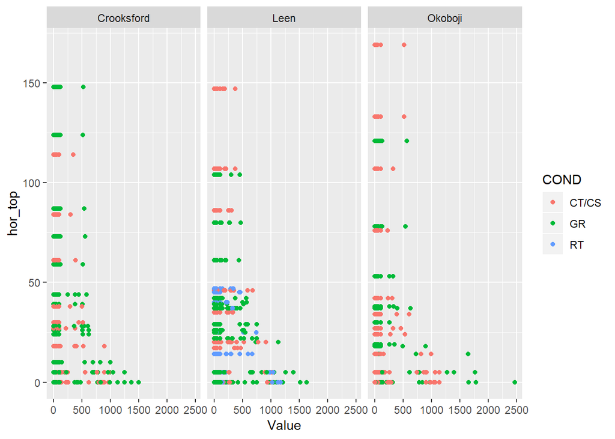

[output not shown]

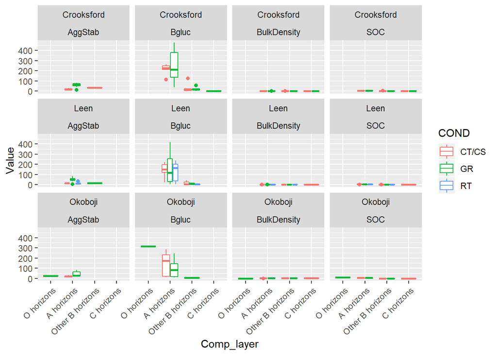

Average Pedon Value for each Plot

| PlotID | MapUnit | Field | COND | Soil | Season | AggStab | Bgluc | BulkDensity | SOC | OM |
| --- | --- | --- | --- | --- | --- | --- | --- | --- | --- | --- |
| CT1 | NA | Conventional Tillage | CT/CS | Crooksford | NA | 21.68 | 96.11 | 1.47 | 1.62 | 2.79 |
| CT2 | NA | Conventional Tillage | CT/CS | Leen | NA | 15.52 | 71.46 | 1.44 | 2.32 | 4.00 |
| CT2 | NA | Conventional Tillage | CT/CS | Okoboji | NA | 26.00 | 245.00 | 0.81 | 5.52 | 9.50 |
| CT3 | NA | Conventional Tillage | CT/CS | Okoboji | NA | 17.94 | 98.45 | 1.35 | 3.11 | 5.36 |
| GR1 | NA | Restored grass | GR | Leen | NA | 39.99 | 68.25 | 1.29 | 2.38 | 4.09 |
| GR1 | NA | Restored grass | GR | Okoboji | NA | 39.67 | Inf | 1.55 | Inf | Inf |
| GR2 | NA | Restored grass | GR | Leen | NA | 52.69 | 70.49 | 1.25 | 3.26 | 5.61 |
| GR3 | h | Restored grass | GR | Crooksford | NA | NaN | NaN | 1.14 | NaN | NaN |
| GR3 | NA | Restored grass | GR | Crooksford | NA | 60.88 | 80.16 | 1.41 | 1.79 | 3.08 |
| RT1 | NA | Ridge Till | RT | Leen | NA | 14.15 | 73.97 | 1.32 | 2.62 | 4.51 |

Pedon Minimum Value for each Plot

| PlotID | MapUnit | Field | COND | Soil | Season | AggStab | Bgluc | BulkDensity | SOC | OM |
| --- | --- | --- | --- | --- | --- | --- | --- | --- | --- | --- |
| CT1 | NA | Conventional Tillage | CT/CS | Crooksford | NA | 12.50 | 84.28 | 1.35 | 0.88 | 1.51 |
| CT2 | NA | Conventional Tillage | CT/CS | Leen | NA | 13.15 | 45.60 | 1.35 | 0.87 | 1.49 |
| CT2 | NA | Conventional Tillage | CT/CS | Okoboji | NA | 26.00 | 245.00 | 0.81 | 5.52 | 9.50 |
| CT3 | NA | Conventional Tillage | CT/CS | Okoboji | NA | 17.94 | 84.03 | 1.24 | 1.73 | 2.98 |
| GR1 | NA | Restored grass | GR | Leen | NA | 38.32 | 65.22 | 1.19 | 2.28 | 3.92 |
| GR1 | NA | Restored grass | GR | Okoboji | NA | 23.36 | 53.81 | 1.49 | 2.64 | 4.54 |
| GR2 | NA | Restored grass | GR | Leen | NA | 35.24 | 59.01 | 1.11 | 2.04 | 3.52 |
| GR3 | h | Restored grass | GR | Crooksford | NA | Inf | Inf | 1.14 | Inf | Inf |
| GR3 | NA | Restored grass | GR | Crooksford | NA | 35.87 | 42.77 | 1.16 | 0.97 | 1.66 |
| RT1 | NA | Ridge Till | RT | Leen | NA | 6.85 | 56.27 | 1.27 | 2.12 | 3.64 |

Pedon Maximum Value for each Plot

| PlotID | MapUnit | Field | COND | Soil | Season | AggStab | Bgluc | BulkDensity | SOC | OM |
| --- | --- | --- | --- | --- | --- | --- | --- | --- | --- | --- |
| CT1 | NA | Conventional Tillage | CT/CS | Crooksford | NA | 28.87 | 117.85 | 1.61 | 2.45 | 4.21 |
| CT2 | NA | Conventional Tillage | CT/CS | Leen | NA | 17.30 | 100.12 | 1.57 | 3.31 | 5.69 |
| CT2 | NA | Conventional Tillage | CT/CS | Okoboji | NA | 26.00 | 245.00 | 0.81 | 5.52 | 9.50 |
| CT3 | NA | Conventional Tillage | CT/CS | Okoboji | NA | 17.94 | 107.66 | 1.49 | 3.93 | 6.76 |
| GR1 | NA | Restored grass | GR | Leen | NA | 43.24 | 70.06 | 1.35 | 2.48 | 4.26 |
| GR1 | NA | Restored grass | GR | Okoboji | NA | 69.44 | Inf | 1.58 | Inf | Inf |
| GR2 | NA | Restored grass | GR | Leen | NA | 77.25 | 89.53 | 1.35 | 3.93 | 6.76 |
| GR3 | h | Restored grass | GR | Crooksford | NA | -Inf | -Inf | 1.14 | -Inf | -Inf |
| GR3 | NA | Restored grass | GR | Crooksford | NA | 77.58 | 147.16 | 1.55 | 3.18 | 5.47 |
| RT1 | NA | Ridge Till | RT | Leen | NA | 27.11 | 89.91 | 1.39 | 3.34 | 5.74 |

## Additional Features Under Development